```python
import tensorflow.keras as keras
from tensorflow.keras.models import load_model

from matplotlib import pyplot as plt
import seaborn as sns
import numpy as np

%matplotlib inline
```

# Network Performance Comparison

To compare our network models, we will use a McNemar test. This allows us to statistically evaluate if there is a significant difference in the proportion of errors made by the classifier, and additionally does not require us to retrain the model *n* times for a sample size and set of metrics (which saves a ton of training time and computational power).

We will define a helper function to calculate the McNemar test statistic, and can then perform hypothesis testing as follows: \begin{aligned}H_{0}&:~p_{b}=p_{c}\\H_{1}&:~p_{b}\neq p_{c}\end{aligned}

The test statistic is calculated as: \begin{aligned}\chi ^{2}={(b-c)^{2} \over b+c}\end{aligned}

where a, b, c, and d are counts of correct and incorrect predictions as can be found at the following source: https://en.wikipedia.org/wiki/McNemar%27s_test

Then, we can use the McNemar statistic as a chi-squared value with one degree of freedom.

```python
from sklearn.metrics import roc_curve, auc

def plotROC(preds_m1, preds_m2, trueVals, label=None):
    # Compute micro-average ROC curve and ROC area

    false_positive_rate, true_positive_rate, thresholds = roc_curve(trueVals, preds_m1)
    roc_auc = auc(false_positive_rate, true_positive_rate)

    plt.plot(false_positive_rate,true_positive_rate, color='red',label = 'CNN Large = %0.2f' % roc_auc)

    false_positive_rate, true_positive_rate, thresholds = roc_curve(trueVals, preds_m2)
    roc_auc = auc(false_positive_rate, true_positive_rate)

    plt.plot(false_positive_rate,true_positive_rate, color='green',label = 'GRU RNN = %0.2f' % roc_auc)


    plt.title('Receiver Op. Char.' + (label if label is not None else ""))
    plt.legend(loc = 'lower right')
    plt.plot([0, 1], [0, 1],linestyle='--')
    plt.axis('tight')
    plt.ylabel('True Positive Rate')
    plt.xlabel('False Positive Rate')


def plotMulticlassROC(model1, model2):

    preds_m1 = model1.predict(X_test)
    preds_m2 = model2.predict(X_test)

    plotsOnLine = 1
    plt.figure(figsize=(15, 3))

    for i in range(19):
        plt.subplot(1, 5, plotsOnLine)

        plotROC(
            preds_m1[:, i],
            preds_m2[:, i],
            np.argmax(y_test, axis=1) == i,
            label=" class " +  str(i),
            )

        if plotsOnLine == 5:
            plotsOnLine = 0
        if plotsOnLine == 0:
            plt.show()
            plt.figure(figsize=(15, 3))
        plotsOnLine += 1


def calcMcNemarStatistic(model1, model2):
    preds_m1 = np.argmax(model1.predict(X_test), axis=1)
    preds_m2 = np.argmax(model2.predict(X_test), axis=1)

    # Get array of where each prediction was correct
    preds_m1_correct = (preds_m1 == np.argmax(y_test, axis=1)).astype(np.bool)
    preds_m2_correct = (preds_m2 == np.argmax(y_test, axis=1)).astype(np.bool)

    # assert lengths same
    assert len(preds_m1_correct) == len(preds_m2_correct)

    # a = test 1 correct and test 2 correct
    a = sum(preds_m1_correct[preds_m2_correct])
    # b = test 1 correct and test 2 incorrect
    b = sum(preds_m1_correct[ ~preds_m2_correct ])
    # c = test 1 incorrect and test 2 correct
    c = sum(preds_m2_correct[ ~preds_m1_correct ])
    # d = test 1 incorrect and test 2 incorrect
    d = sum(~preds_m1_correct[~preds_m2_correct])

    # ensure totals are correct
    assert (a+b+c+d == len(preds_m1_correct))

    # ensure that b+c >= 25 so that a chi sq can be approximated
    #assert (b+c >= 25)

    chisq = (b - c) ** 2
    chisq /= (b + c)

    return chisq

from scipy.stats import chi2 as statChiSquared
def getProb(chiSq, df=1):
    return 1 - statChiSquared.cdf(chiSq, df)

def getAccuracy(model):
    preds = model.predict(X_test)
    preds = np.argmax(preds, axis=1)
    return sum(preds == np.argmax(y_test, axis=1)) / len(preds)
```

```python
from sklearn import metrics as mt

def plotConfusions(model):

    plt.figure(figsize=(13, 10))

    yhat = np.argmax(model.predict(X_test), axis=1)
    acc = mt.accuracy_score(np.argmax(y_test, axis=1), yhat)
    cm = mt.confusion_matrix(np.argmax(y_test, axis=1), yhat)
    cm = cm/np.sum(cm,axis=1)[:,np.newaxis]
    sns.heatmap(cm, annot=True, fmt='.2f')
    plt.title('Accuracy: '+str(acc))

    plt.show()
```

```python
def fullTest(model1, model2, alpha=0.05):
    stat = calcMcNemarStatistic(model1, model2)
    prob = getProb(stat)
    print("Model Accuracy:")
    print("\tModel One:", getAccuracy(model1))
    print("\tModel Two:", getAccuracy(model2))
    print("Chi-Squared Test")
    print("\tdf=1, chi-squared val:", stat)
    print("\talpha="+str(alpha))
    print("\tProbability:", prob)
    print("\tWe " + ("REJECT" if (prob < alpha) else "FAIL TO REJECT") + " the null hypothesis, which states that the models perform similarly.")
```

```python
X_test = np.load('xTest.npy')
y_test = np.load('yTest.npy')
```

# Statistical Difference Measures

```python
if 'cnnSmall' not in locals():
    cnnSmall = load_model('models/cnnSmall')
    cnnMedium = load_model('models/cnnMed')
    cnnLarge = load_model('models/cnnLarge')
    rnnLSTM = load_model('models/rnnLSTM')
    rnnGRU = load_model('models/rnnGRU')

    cnnSmallWrinkle = load_model('models/cnnSmall_wrinkle')
    cnnMediumWrinkle = load_model('models/cnnMed_wrinkle')
    cnnLargeWrinkle = load_model('models/cnnLarge_wrinkle')
    rnnLSTMWrinkle = load_model('models/rnnLSTM_wrinkle')
    rnnGRUWrinkle = load_model('models/rnnGRU_wrinkle')

    cnnSmallPreproc = load_model('models/cnnSmall_preproc')
    cnnMediumPreproc = load_model('models/cnnMed_preproc')
    cnnLargePreproc = load_model('models/cnnLarge_preproc')
    rnnLSTMPreproc = load_model('models/rnnLSTM_preproc')
    rnnGRUPreproc = load_model('models/rnnGRU_preproc')
```

[output not shown]

# Standard Model Comparisons

```python
fullTest(cnnSmall, cnnLarge) # note: large outperforms small
```

```
Model Accuracy:
	Model One: 0.82
	Model Two: 0.86
Chi-Squared Test
	df=1, chi-squared val: 8.0
	alpha=0.05
	Probability: 0.004677734981047288
	We REJECT the null hypothesis, which states that the models perform similarly.
```

```python
fullTest(cnnSmall, cnnMedium) # note: small outperforms medium
```

```
Model Accuracy:
	Model One: 0.82
	Model Two: 0.765
Chi-Squared Test
	df=1, chi-squared val: 8.962962962962964
	alpha=0.05
	Probability: 0.0027550771035609323
	We REJECT the null hypothesis, which states that the models perform similarly.
```

```python
fullTest(cnnLarge, rnnLSTM) # cnn outperforms lstm
```

```
Model Accuracy:
	Model One: 0.86
	Model Two: 0.7975
Chi-Squared Test
	df=1, chi-squared val: 11.363636363636363
	alpha=0.05
	Probability: 0.0007489604476389466
	We REJECT the null hypothesis, which states that the models perform similarly.
```

```python
fullTest(cnnLarge, rnnGRU) # cnn performs similarly to GRU
```

```
Model Accuracy:
	Model One: 0.86
	Model Two: 0.8525
Chi-Squared Test
	df=1, chi-squared val: 0.23076923076923078
	alpha=0.05
	Probability: 0.6309540411841706
	We FAIL TO REJECT the null hypothesis, which states that the models perform similarly.
```

# Preprocessing Model Comparisons

We observe that adding preprocessing decreases performance by a statistically significant margin in every case. It appears to be better to let the neural networks / embeddings use full, unprocessed texts.

```python
fullTest(cnnSmall, cnnSmallPreproc)
```

```
Model Accuracy:
	Model One: 0.82
	Model Two: 0.7475
Chi-Squared Test
	df=1, chi-squared val: 12.18840579710145
	alpha=0.05
	Probability: 0.0004808746178788237
	We REJECT the null hypothesis, which states that the models perform similarly.
```

```python
fullTest(cnnMedium, cnnMediumPreproc)
```

```
Model Accuracy:
	Model One: 0.765
	Model Two: 0.4675
Chi-Squared Test
	df=1, chi-squared val: 108.09923664122137
	alpha=0.05
	Probability: 0.0
	We REJECT the null hypothesis, which states that the models perform similarly.
```

```python
fullTest(cnnLarge, cnnLargePreproc)
```

```
Model Accuracy:
	Model One: 0.86
	Model Two: 0.6875
Chi-Squared Test
	df=1, chi-squared val: 50.11578947368421
	alpha=0.05
	Probability: 1.4493961586481419e-12
	We REJECT the null hypothesis, which states that the models perform similarly.
```

```python
fullTest(rnnLSTM, rnnLSTMPreproc)
```

```
Model Accuracy:
	Model One: 0.7975
	Model Two: 0.745
Chi-Squared Test
	df=1, chi-squared val: 7.0
	alpha=0.05
	Probability: 0.008150971593502754
	We REJECT the null hypothesis, which states that the models perform similarly.
```

```python
fullTest(rnnGRU, rnnGRUPreproc)
```

```
Model Accuracy:
	Model One: 0.8525
	Model Two: 0.795
Chi-Squared Test
	df=1, chi-squared val: 9.618181818181819
	alpha=0.05
	Probability: 0.0019266037648594248
	We REJECT the null hypothesis, which states that the models perform similarly.
```

# Wrinkle Model Comparisons

```python
fullTest(cnnSmall, cnnSmallWrinkle) # wrinkle doesn't have significant impact until alpha > 0.052
print()
fullTest(cnnSmall, cnnSmallWrinkle, alpha=0.1)
```

```
Model Accuracy:
	Model One: 0.82
	Model Two: 0.85
Chi-Squared Test
	df=1, chi-squared val: 3.789473684210526
	alpha=0.05
	Probability: 0.05157586362087696
	We FAIL TO REJECT the null hypothesis, which states that the models perform similarly.

Model Accuracy:
	Model One: 0.82
	Model Two: 0.85
Chi-Squared Test
	df=1, chi-squared val: 3.789473684210526
	alpha=0.1
	Probability: 0.05157586362087696
	We REJECT the null hypothesis, which states that the models perform similarly.
```

```python
fullTest(cnnMedium, cnnMediumWrinkle) # wrinkle has no statistical impact here
```

```
Model Accuracy:
	Model One: 0.765
	Model Two: 0.7575
Chi-Squared Test
	df=1, chi-squared val: 0.36
	alpha=0.05
	Probability: 0.5485062355001471
	We FAIL TO REJECT the null hypothesis, which states that the models perform similarly.
```

```python
fullTest(cnnLarge, cnnLargeWrinkle) # wrinkle has no statistical impact here
```

```
Model Accuracy:
	Model One: 0.86
	Model Two: 0.8525
Chi-Squared Test
	df=1, chi-squared val: 0.2727272727272727
	alpha=0.05
	Probability: 0.6015081344405899
	We FAIL TO REJECT the null hypothesis, which states that the models perform similarly.
```

```python
fullTest(rnnLSTM, rnnLSTMWrinkle) # wrinkle has statistically significant positive impact here
```

```
Model Accuracy:
	Model One: 0.7975
	Model Two: 0.8325
Chi-Squared Test
	df=1, chi-squared val: 6.533333333333333
	alpha=0.05
	Probability: 0.010587137334056917
	We REJECT the null hypothesis, which states that the models perform similarly.
```

```python
fullTest(rnnGRU, rnnGRUWrinkle) # wrinkle has no statistical impact here
```

```
Model Accuracy:
	Model One: 0.8525
	Model Two: 0.8575
Chi-Squared Test
	df=1, chi-squared val: 0.18181818181818182
	alpha=0.05
	Probability: 0.6698153575994166
	We FAIL TO REJECT the null hypothesis, which states that the models perform similarly.
```

# Model Architecture Visualizations

```python
%pip install pydot --user
```

```
CNN SMALL
```

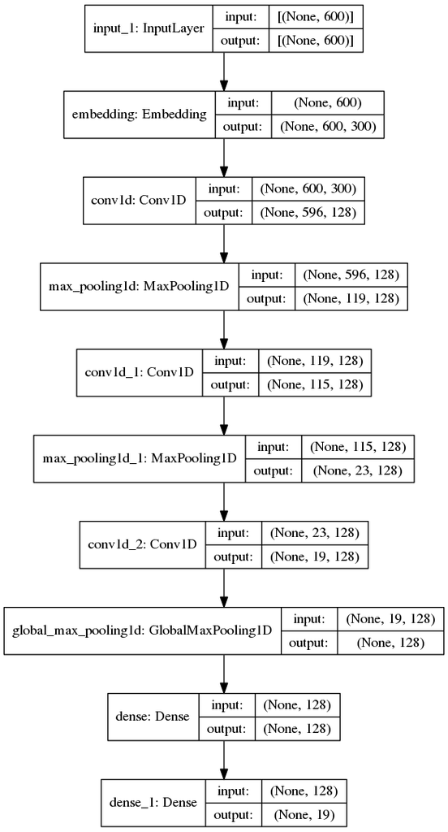

```python
from IPython.display import SVG
from tensorflow.keras.utils import plot_model

print("CNN SMALL")
plot_model(cnnSmall, show_shapes=True)
```

```
CNN MEDIUM
```

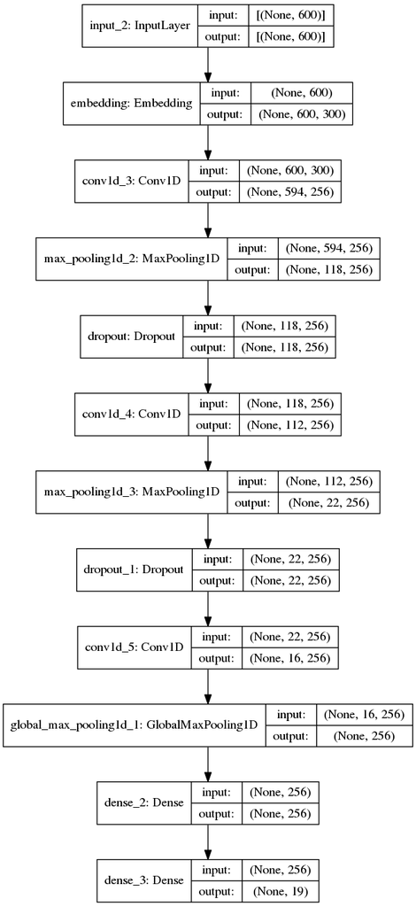

```python
print("CNN MEDIUM")
plot_model(cnnMedium, show_shapes=True)
```

```
CNN LARGE
```

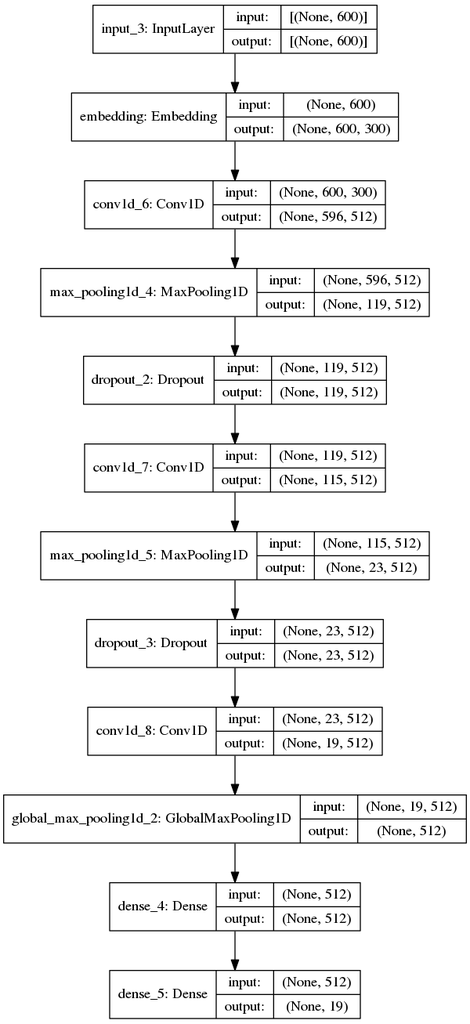

```python
print("CNN LARGE")
plot_model(cnnLarge, show_shapes=True)
```

```
RNN LSTM
```

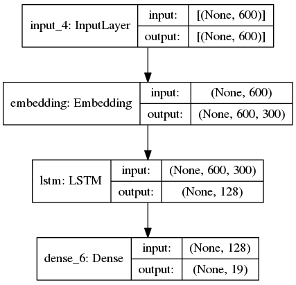

```python
print("RNN LSTM")
plot_model(rnnLSTM, show_shapes=True)
```

```
RNN GRU
```

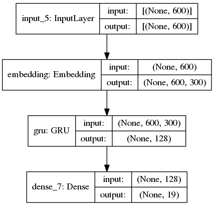

```python
print("RNN GRU")
plot_model(rnnGRU, show_shapes=True)
```

# CNN - Large (Most Effective Model) Visualizations

Plus comparisons to the gated-recurrent unit RNN (the second best model, not statistically worse).

```
CNN
```

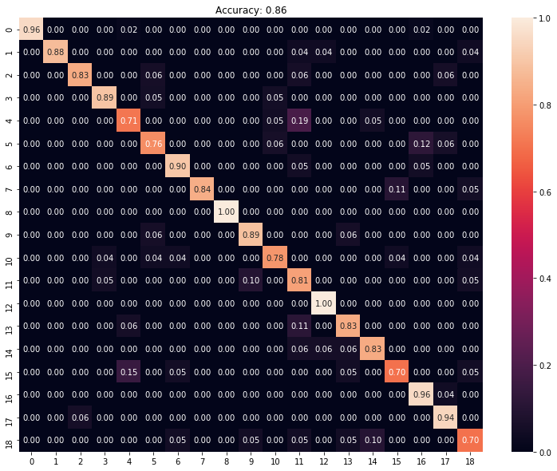

```
RNN
```

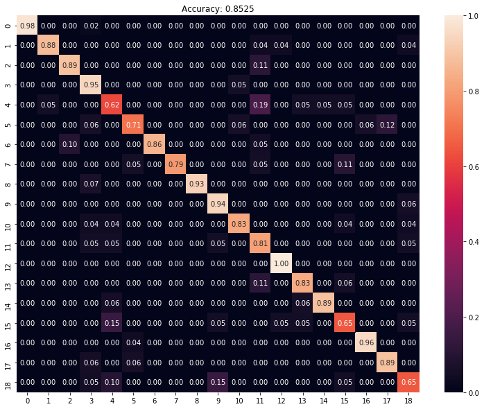

```python
print("CNN")
plotConfusions(cnnLarge)
print()
print("RNN")
plotConfusions(rnnGRU)
```

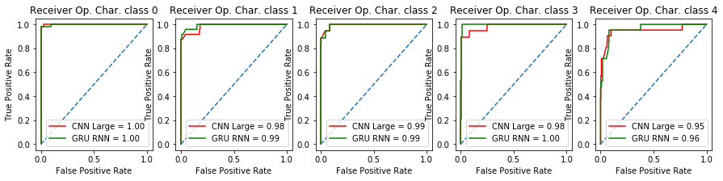

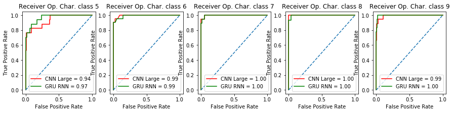

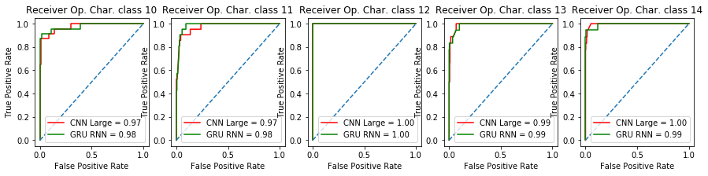

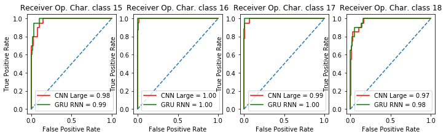

```python
# cnn large vs GRU rnn receiver operating curves
# note CNN Large is best model and GRU RNN is second best
plotMulticlassROC(cnnLarge, rnnGRU)
```

# CNN - Small with Wrinkle vs Small without Wrinkle

The wrinkle had a statistically significant impact (at alpha = 0.075) on the small CNN. Here, we plot ROC to compare the two on each case.

[figure not shown]

[figure not shown]

[figure not shown]

[figure not shown]

```python
plotMulticlassROC(cnnSmallWrinkle, cnnSmall)
```